# ST327 Individual Project — Public Attitudes to AI

A revolution unlike its predecessors

Working notes

2026-04-25

# 1 Discussion of the research aims

## 1.1 Why this matters

AI is, by most accounts, the **fourth industrial revolution** — and the first one to threaten knowledge work as much as manual work. Past technological shifts hit specific groups: skilled artisans during 19th century mechanisation, factory workers during 20th century automation. Decades of attitudes-to-technology research have shown a robust pattern in their wake — educated and affluent groups have been consistently more enthusiastic about new technology, working-class groups more skeptical.

What makes AI different is its breadth. Large language models target the cognitive tasks that have until recently been among the safest jobs in a developed economy: legal drafting, copywriting, junior coding, financial analysis, customer service, parts of teaching and medicine. The exposure profile is unfamiliar — and the public’s response is a question worth asking carefully, with practical consequences for businesses (who is adopting, who is resisting), policymakers (who is worried, who needs reassurance), and the AI industry itself (whose trust it has yet to win).

## 1.2 The research questions

The brief sets five aims. Read together, they map onto three substantive public-facing questions and two analytical moves that sharpen the answers.

**Substantive questions**

1. **Who is adopting AI?** *(Aim 1 — usage)*
2. **What does the public think about its benefits, risks and impact on society?** *(Aim 2 — attitudes)*
3. **How does the public want AI to be governed?** *(Aim 3 — governance)*

**Analytical moves to deepen the answers**

4. **Segment the public by mindset** to identify distinct attitudinal groups beyond the aggregate numbers *(Aim 4 — clusters)*.
5. **Listen to the public’s own words** about hopes and concerns, and link these back to the segments *(Aim 5 — open text)*.

## 1.3 How the questionnaire serves the aims

The instrument has clear strengths and one notable gap.

**Strengths.** Q1 gives a clean ordinal usage measure. Q2 is a 10-item Likert battery that splits cleanly into a coherent positivity scale and a wider concerns set. Q3 enumerates institutional actors. Q5 is genuinely open-ended. The full demographic suite supports detailed cross-cuts without leaning on a single classification.

**Notable gap.** Q1 measures *frequency* of AI use, not *purpose*. We can identify who uses AI more; we cannot identify why. Any functional reading (study tool, work tool, companionship) is a hypothesis, not a finding. This shapes the language throughout the report.

## 1.4 Approach

This report addresses each aim in turn, with the brief’s own emphasis guiding how much space each analysis gets.

| Aim | Brief’s emphasis | What this report leads with |
| --- | --- | --- |
| 1 Usage | “differences across the population” | Full demographic sweep |
| 2 Attitudes | “how people evaluate AI” | Overall picture, scale structure, then a deep dive on who is worried about jobs |
| 3 Governance | “relates to broader attitudes” | Q3 × Q2 cross-references |
| 4 Clusters | “selected demographic variables” | Named clusters, five-variable profile |
| 5 Open text | “relate back to the groups in (4)” | Themes × clusters |

**Cleaning.** Supplier FIX codes recoded to missing (Q1 values 8/9, Q2 value 6, Q4 value 99). Demographics converted to labelled factors against the official codebook. Ordinal usage binned to `Weekly+ / Occasional / Never` for visual clarity; the underlying 1–7 scale is used in regression.

# 2 Sample profile

Age band

| Age | n | pct |
| --- | --- | --- |
| 18-24 | 50 | 8.8 |
| 25-34 | 81 | 14.2 |
| 35-44 | 98 | 17.2 |
| 45-54 | 95 | 16.7 |
| 55-64 | 101 | 17.8 |
| 65+ | 144 | 25.3 |

Gender

| Gender | n | pct |
| --- | --- | --- |
| Male | 297 | 52.2 |
| Female | 271 | 47.6 |
| Other | 1 | 0.2 |

Social grade (SEG)

| SEG | n | pct |
| --- | --- | --- |
| A | 55 | 9.7 |
| B | 97 | 17.0 |
| C1 | 165 | 29.0 |
| C2 | 126 | 22.1 |
| D | 72 | 12.7 |
| E | 54 | 9.5 |

Highest education

| Education | n | pct |
| --- | --- | --- |
| No formal | 7 | 1.2 |
| Primary | 2 | 0.4 |
| Secondary/GCSE/A-level | 245 | 43.1 |
| University degree | 204 | 35.9 |
| Higher degree/doctorate | 95 | 16.7 |
| Still in FT education | 10 | 1.8 |
| Don’t know | 3 | 0.5 |
| Refused | 3 | 0.5 |

Working status

| Work status | n | pct |
| --- | --- | --- |
| FT employee (30+h) | 229 | 40.2 |
| PT employee (8-29h) | 88 | 15.5 |
| Self-emp FT | 22 | 3.9 |
| Self-emp PT | 15 | 2.6 |
| Unemployed / seeking | 14 | 2.5 |
| Not working / not seeking | 28 | 4.9 |
| Student | 20 | 3.5 |
| Retired (state) | 30 | 5.3 |
| Retired (private) | 107 | 18.8 |
| Homemaker | 16 | 2.8 |

Household income band

| Income | n | pct |
| --- | --- | --- |
| Under £21k | 103 | 19.7 |
| £21k-£41k | 178 | 34.1 |
| £41k-£62k | 132 | 25.3 |
| £62k-£83k | 63 | 12.1 |
| £83k+ | 46 | 8.8 |

Ethnicity (collapsed)

| Ethnicity | n | pct |
| --- | --- | --- |
| White | 497 | 88.6 |
| Minority ethnic | 64 | 11.4 |

Ethnicity (full detail, 27 categories)

| Ethnicity | n | pct |
| --- | --- | --- |
| English | 323 | 57.0 |
| Welsh | 20 | 3.5 |
| Scottish | 38 | 6.7 |
| Northern Irish | 18 | 3.2 |
| British | 84 | 14.8 |
| Irish | 3 | 0.5 |
| Irish Traveller or Gypsy | 1 | 0.2 |
| Any other White background | 10 | 1.8 |
| Bangladeshi | 4 | 0.7 |
| Indian | 12 | 2.1 |
| Pakistani | 6 | 1.1 |
| Any other Asian background | 2 | 0.4 |
| African | 14 | 2.5 |
| Caribbean | 1 | 0.2 |
| Asian and White | 6 | 1.1 |
| Black African and White | 1 | 0.2 |
| Black Caribbean and White | 1 | 0.2 |
| Any other mixed or multiple background | 1 | 0.2 |
| Chinese | 13 | 2.3 |
| Arab | 3 | 0.5 |
| Prefer not to say | 6 | 1.1 |

Any long-standing condition

| Disability | n | pct |
| --- | --- | --- |
| No | 427 | 75 |
| Yes | 142 | 25 |

Disability sub-categories

|  | Disability type | % selecting |
| --- | --- | --- |
| demogs_disability1 | NET: any disability | 25.0 |
| demogs_disability2 | Mental condition | 9.8 |
| demogs_disability3 | Physical condition | 16.5 |
| demogs_disability4 | Disability (unspecified) | 7.0 |
| demogs_disability5 | Other | 1.2 |
| demogs_disability6 | No disability | 73.3 |
| demogs_disability7 | Refused | 1.8 |

Any child aged 18 or under

| Children | n | pct |
| --- | --- | --- |
| No | 427 | 75 |
| Yes | 142 | 25 |

Children in household

|  | Children category | % selecting |
| --- | --- | --- |
| demogs_children1 | No children aged 18 or under | 75.0 |
| demogs_children2 | Children under 5 | 7.2 |
| demogs_children3 | Children aged 5-10 | 12.0 |
| demogs_children4 | Children aged 11-15 | 9.0 |
| demogs_children5 | Children aged 16-18 | 6.3 |
| demogs_children6 | Refused | 0.2 |

Marital status (collapsed)

| Marital | n | pct |
| --- | --- | --- |
| Single/other | 238 | 42 |
| Married/cohabiting | 328 | 58 |

## 2.1 Variables excluded from the analysis

Correlations between excluded variables and SEG/income/age

|  | demogs_hols | demogs_cars | demogs_town | demogs_seg | demogs_income | demogs_age |
| --- | --- | --- | --- | --- | --- | --- |
| demogs_hols | 1.00 | -0.14 | 0.11 | 0.25 | -0.28 | 0.17 |
| demogs_cars | -0.14 | 1.00 | 0.17 | -0.17 | 0.27 | -0.10 |
| demogs_town | 0.11 | 0.17 | 1.00 | 0.06 | -0.13 | 0.21 |
| demogs_seg | 0.25 | -0.17 | 0.06 | 1.00 | -0.29 | 0.11 |
| demogs_income | -0.28 | 0.27 | -0.13 | -0.29 | 1.00 | -0.21 |
| demogs_age | 0.17 | -0.10 | 0.21 | 0.11 | -0.21 | 1.00 |

Ethnicity, disability, children-in-household and marital status are *kept* because they carry distinct information (lived experience with algorithmic bias, assistive-technology exposure, household context) that is not a re-expression of SEG or income.

# 3 Aim 1 — How people use AI

*The adoption phase of the revolution: who is already inside, who is not, and where the lines run.*

The brief explicitly asks for *differences across the population*. This is the one section where full demographic sweep is the deliverable.

## 3.1 Overall usage distribution

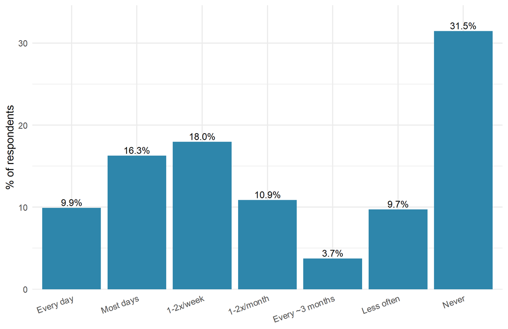

Q1: How often do you use AI? (%)

Headline usage statistics

| Metric | Value |
| --- | --- |
| % weekly+ (codes 1-3) | 44.2% |
| % occasional (4-6) | 24.3% |
| % never (7) | 31.5% |
| % any use (1-6) | 68.5% |
| n valid | 534 |

**Reading.** The public splits into roughly three camps: weekly users, occasional users, and never-users. Daily/most-day use is now a mass-adoption pattern. The “Never” group is large enough that any policy narrative assuming the whole public uses AI is wrong for about a third of adults.

> **Limitation.** Everything below describes *frequency*, not *purpose*. A daily user is someone who opens an AI tool most days — for coursework, work, emotional support, entertainment, or curiosity — and this survey cannot distinguish those uses.

## 3.2 Usage by age

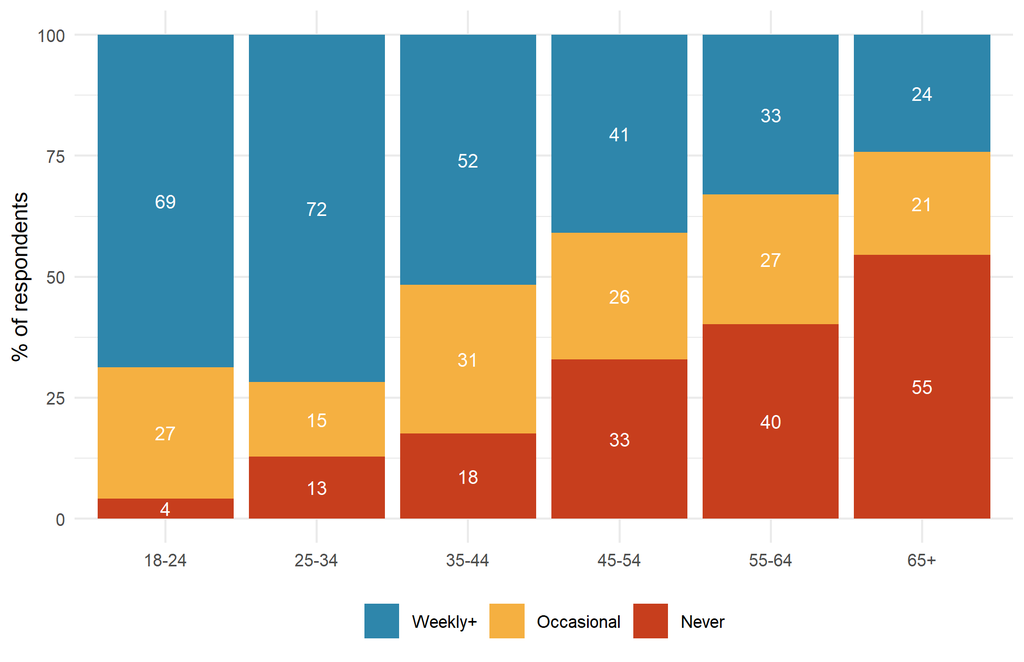

Usage intensity by age band (%)

Age is the steepest gradient. Weekly+ use falls from roughly 70% among 18–34s to roughly 24% among 65+; the over-65 group has a majority Never rate.

## 3.3 Usage by SEG

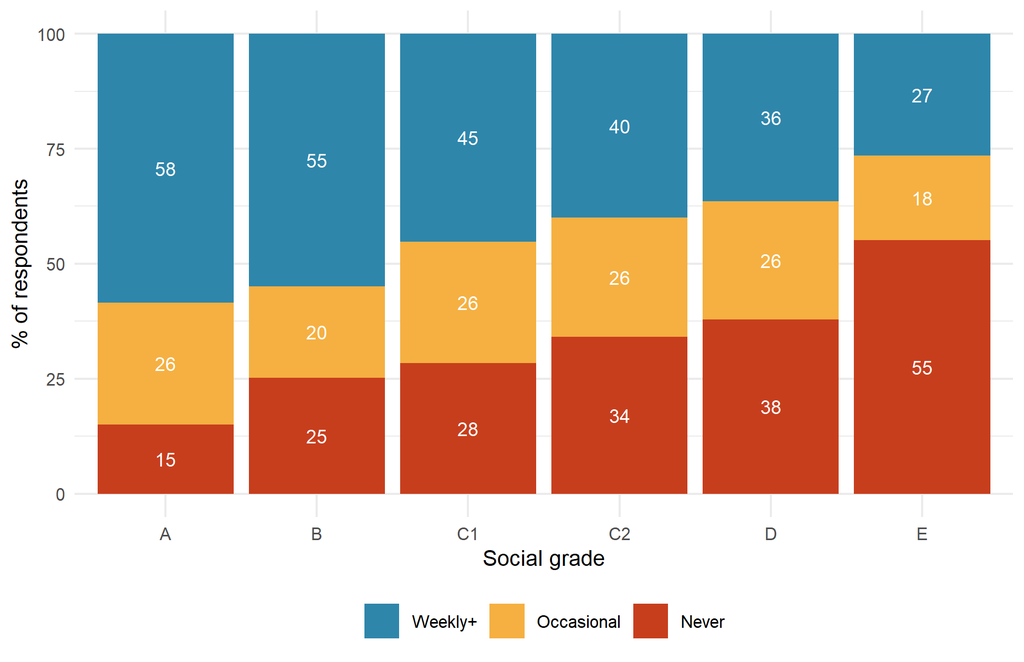

Usage intensity by social grade (%)

## 3.4 Usage by education — two hypotheses

Two distinct questions live inside the education variable, and they deserve separate tests.

- **Human-capital hypothesis:** does *completed* education predict usage? (Compare GCSE vs University vs Higher degree.)
- **Tool-for-study hypothesis:** do people currently in FT education use AI more than similar-age non-students? (Student vs non-student, 18–34 only, to strip out age.)

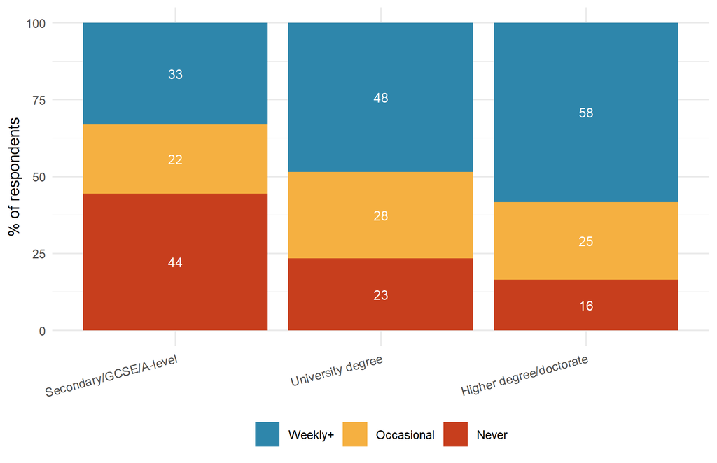

Usage by completed education level (%)

Clear gradient across the three completed tiers: weekly+ use rises with each qualification step. Education and SEG overlap by construction, so the regression below tells us whether education adds independent signal.

Current students vs non-students, 18-34 only

| student | pct_Weekly+ | pct_Occasional | pct_Never | n_Weekly+ | n_Occasional | n_Never |
| --- | --- | --- | --- | --- | --- | --- |
| Non-student | 70.1 | 19.7 | 10.3 | 82 | 23 | 12 |
| Current student | 77.8 | 22.2 | NA | 7 | 2 | NA |

|  | Test | Statistic | df | p-value |
| --- | --- | --- | --- | --- |
| X-squared | Chi-square (student × usage, 18-34 only) | 1.02 | 2 | 0.6003 |

**Reading.** Restricting to 18–34s isolates the student effect from the age effect. If current students still use AI more than age-matched non-students, this is *consistent with* the tool-for-study hypothesis — but we cannot distinguish study use from other student-typical uses (emotional support, entertainment) with a frequency question. Read this as an association, not a mechanism.

## 3.5 Usage by working status

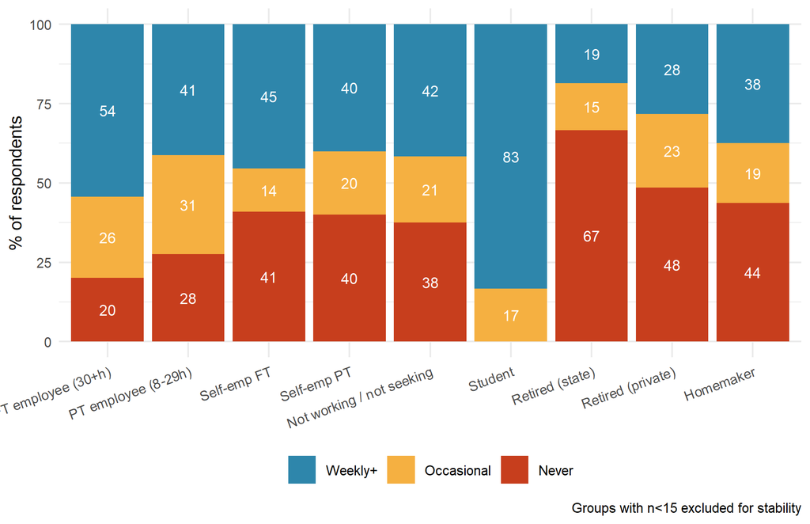

Usage intensity by working status (%)

Students and full-time employees are the heaviest users; retirees the lightest — largely an age echo. Whether heavier usage among white- collar workers reflects job demands, personal overflow, or higher digital literacy is not identifiable from this data.

## 3.6 Usage by household income

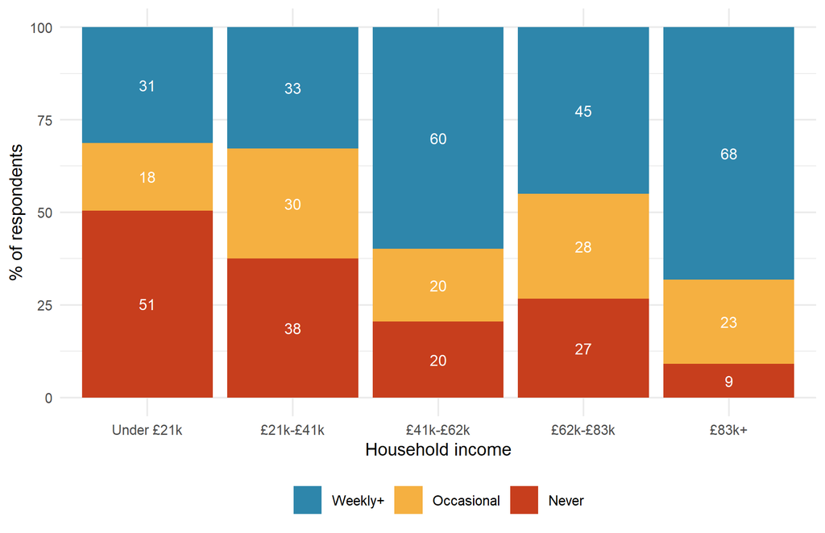

Usage intensity by household income (%)

Reinforces the SEG story: weekly+ use roughly doubles from the lowest band to the highest.

## 3.7 Chi-square tests: usage × primary demographics

Chi-square tests: usage × demographics

|  | Variable | Chi-square | df | p-value | n |
| --- | --- | --- | --- | --- | --- |
| age_band | Age | 91.48 | 10 | 0.000 | 534 |
| seg | SEG | 27.69 | 10 | 0.002 | 534 |
| gender | Gender | NaN | 6 | NaN | 534 |
| education | Education | 49.31 | 14 | 0.000 | 534 |
| work_status | Working status | NaN | 22 | NaN | 534 |
| income_band | Household income | 51.45 | 8 | 0.000 | 493 |

## 3.8 Secondary demographics (brief check)

Tested once as a robustness check, not featured.

Q1 × secondary demographics

|  | Variable | Levels | Chi-square | df | p-value |
| --- | --- | --- | --- | --- | --- |
| X-squared…1 | Ethnicity | White=40.9 \| Minority ethnic=67.2 | 24.70 | 2 | 0.0000 |
| X-squared…2 | Disability | No=46.1 \| Yes=38.7 | 7.61 | 2 | 0.0222 |
| X-squared…3 | Children in household | No=38.8 \| Yes=60.6 | 21.22 | 2 | 0.0000 |
| X-squared…4 | Marital status | Single/other=44.5 \| Married/cohabiting=43.8 | 2.23 | 2 | 0.3275 |

Three of four are significant at the bivariate level (ethnicity, children, disability). All three are substantially confounded with age and SEG — they do not survive multivariate adjustment (see regression below). Marital status produces no meaningful raw gap.

## 3.9 News-source diet

Not a brief-mandated axis, but a strong association worth flagging: media consumption style predicts AI usage more sharply than most demographics.

AI weekly+ usage by news-source diet

| Source | % Weekly+ (uses) | % Weekly+ (doesn’t) | Δ (pp) | p-value |
| --- | --- | --- | --- | --- |
| Traditional TV / radio news | 41.8 | 48.9 | -7.1 | 0.0450 |
| Broadsheet newspapers | 50.8 | 43.3 | 7.5 | 0.1922 |
| Any social-media news | 54.1 | 32.4 | 21.7 | 0.0000 |
| TikTok for news | 68.6 | 40.5 | 28.1 | 0.0000 |
| Reddit for news | 77.8 | 40.4 | 37.4 | 0.0000 |

## 3.10 Independent effects — ordinal logistic regression

All demographics together on the 7-point Q1 scale.

Ordinal logistic regression. Positive estimates = less frequent use.

| term | estimate | std.error | odds_ratio | p_value | sig |
| --- | --- | --- | --- | --- | --- |
| age_band25-34 | 0.11 | 0.35 | 1.11 | 0.7570 |  |
| age_band35-44 | 0.69 | 0.35 | 2.00 | 0.0461 | * |
| age_band45-54 | 1.17 | 0.35 | 3.21 | 0.0010 | ** |
| age_band55-64 | 1.20 | 0.35 | 3.32 | 0.0007 | *** |
| age_band65+ | 1.83 | 0.36 | 6.26 | 0.0000 | *** |
| genderFemale | 0.54 | 0.17 | 1.72 | 0.0011 | ** |
| genderOther | 0.47 | 1.47 | 1.60 | 0.7502 |  |
| segB | 0.30 | 0.33 | 1.35 | 0.3524 |  |
| segC1 | 0.33 | 0.31 | 1.39 | 0.2952 |  |
| segC2 | 0.61 | 0.32 | 1.84 | 0.0583 |  |
| segD | 0.69 | 0.36 | 1.99 | 0.0543 |  |
| segE | 1.10 | 0.43 | 3.00 | 0.0098 | ** |
| educationPrimary | -0.10 | 1.38 | 0.91 | 0.9444 |  |
| educationSecondary/GCSE/A-level | 0.87 | 0.84 | 2.40 | 0.2978 |  |
| educationUniversity degree | 0.28 | 0.84 | 1.32 | 0.7416 |  |
| educationHigher degree/doctorate | 0.10 | 0.86 | 1.10 | 0.9113 |  |
| educationStill in FT education | -0.36 | 1.11 | 0.70 | 0.7453 |  |
| educationDon’t know | 1.82 | 1.66 | 6.15 | 0.2742 |  |
| educationRefused | -0.48 | 1.41 | 0.62 | 0.7303 |  |
| ethnicity_grpMinority ethnic | -0.47 | 0.27 | 0.63 | 0.0882 |  |
| has_disabilityYes | 0.04 | 0.21 | 1.04 | 0.8655 |  |
| has_childrenYes | -0.39 | 0.23 | 0.67 | 0.0918 |  |
| marital_grpMarried/cohabiting | 0.02 | 0.19 | 1.02 | 0.9069 |  |

## 3.11 Aim 1 summary

AI adoption in the UK is sharply stratified by age, SEG, education and news-consumption style. Ethnicity, disability, children in household and marital status do not add independent signal. Gender matters once SEG is controlled. The “digital divide” label fits — access to the AI transition is concentrated among the young, the educated and the higher-SEG.

# 4 Aim 2 — Attitudes towards AI

*The hopes and fears the revolution generates — how the public weighs opportunity, risk, trust and impact.*

The brief asks *how people evaluate AI*. The deliverable here is the overall picture; demographic variation is secondary and handled compactly. We then take a deeper look at the one item that bears most directly on the labour-displacement narrative: who agrees that AI will reduce jobs?

## 4.1 Full response distributions

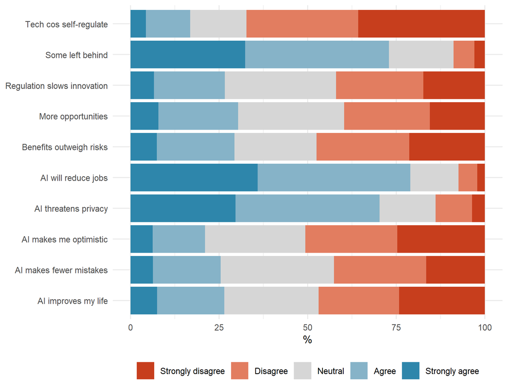

Q2: full distribution per item (%)

## 4.2 How we summarise the 10 Q2 items

Ten items per respondent is too many to compare across demographics one at a time. The rest of Aim 2 follows a deliberate funnel from broad to focused.

**Step 1 — net-agree per item (next sub-section).** A simple % agree minus % disagree score for each of the ten items, ordered. This shows which specific statements the public agrees with most strongly. The unit of analysis is the *item*.

**Step 2 — scale structure (Cronbach’s α).** We then test whether the ten items collapse cleanly into latent dimensions. They do — into two:

- **Positivity scale** — q2_02 (“AI improves my life”), q2_05 (“more opportunities”), q2_06 (“AI makes me optimistic”), q2_07 (“benefits outweigh risks”), q2_09 (“AI makes fewer mistakes”). Pro-AI items that move together (α = 0.92).
- **Concern scale** — q2_01 (“some left behind”), q2_08 (“AI threatens privacy”), q2_10 (“AI will reduce jobs”). Items about societal worry, looser internal consistency (α = 0.55) — meaning people pick the concern that speaks to them rather than holding a uniform anti-AI view.

**Step 3 — demographic variation, summarised.** With the two scales established, we report **Positivity mean** and **Concern mean** by age, gender and SEG. Both are means on the original 1–5 Likert scale (1 = strongly disagree, 5 = strongly agree), so 4.0 means the average respondent in that group is around “tend to agree” with the items in that scale. This lets us see at a glance whether a group leans more pro-AI, more concerned, or both at once — without having to read 30 demographic-by-item tables.

**Step 4 — focused deep dive on one item.** The compact summary flattens detail by design. So after the summary, we zoom into the single item with the strongest substantive stakes — q2_10, “AI will reduce jobs” — and test it against SEG, working status and education on its own.

**Step 5 — Q4 semantic differential.** A separate 1–10 scale battery covering benefit, safety, impact, inequality and excitement. Reported as means.

The same two scales (Positivity, Concern) reappear in Aim 3 (where we cross them with governance preferences) and feed the Aim 4 cluster solution.

## 4.3 Net-agree scores

Q2 net-agree (% agree - % disagree)

|  | Item | Net-agree (%) |
| --- | --- | --- |
| q2_10 | AI will reduce jobs | 71.6 |
| q2_01 | Some left behind | 64.1 |
| q2_08 | AI threatens privacy | 56.5 |
| q2_05 | More opportunities | -9.3 |
| q2_03 | Regulation slows innovation | -15.4 |
| q2_09 | AI makes fewer mistakes | -17.2 |
| q2_07 | Benefits outweigh risks | -18.2 |
| q2_02 | AI improves my life | -20.4 |
| q2_06 | AI makes me optimistic | -29.6 |
| q2_04 | Tech cos self-regulate | -50.4 |

## 4.4 Scale structure — two latent constructs

Cronbach’s alpha

| Scale | Alpha |
| --- | --- |
| All 10 Q2 items (auto-reversed) | 0.88 |
| Positive sub-scale (q2_02/05/06/07/09) | 0.92 |
| Concern sub-scale (q2_01/08/10) | 0.55 |

**Key finding.** Positivity is a clean unidimensional scale (α = 0.92). Concerns are a grab-bag (α = 0.55) — people pick the concern that speaks to them rather than holding a uniform anti-AI view. This itself is a substantive finding: **there is no coherent anti-AI public**, only a coherent pro-AI public and a fragmented landscape of specific concerns.

## 4.5 Demographic variation — compact summary

Positivity and concern means by main demographics

| Variable | Group | Positivity mean | Concern mean | n |
| --- | --- | --- | --- | --- |
| Age | 18-24 | 3.10 | 3.73 | 50 |
| Age | 25-34 | 3.06 | 3.85 | 81 |
| Age | 35-44 | 2.83 | 3.93 | 98 |
| Age | 45-54 | 2.65 | 3.79 | 95 |
| Age | 55-64 | 2.46 | 4.03 | 101 |
| Age | 65+ | 2.35 | 4.08 | 144 |
| Gender | Male | 2.82 | 3.89 | 297 |
| Gender | Female | 2.51 | 3.98 | 271 |
| Gender | Other | 2.00 | 4.00 | 1 |
| SEG | A | 3.07 | 3.84 | 55 |
| SEG | B | 2.92 | 3.86 | 97 |
| SEG | C1 | 2.60 | 4.01 | 165 |
| SEG | C2 | 2.57 | 3.92 | 126 |
| SEG | D | 2.66 | 3.81 | 72 |
| SEG | E | 2.28 | 4.14 | 54 |

**Reading.** Positivity varies strongly with age and SEG: 18–34s and grade A score ~0.7 higher than 65+ and grade E on a 1–5 scale. Concern scores are much flatter across demographic groups. Concerns are broadly shared; optimism is stratified.

Secondary demographics (ethnicity, disability, children, marital) produce some significant ANOVA results on individual items — most notably children-in-household (significant on 8 of 10 items) — but these are excluded from the main narrative because Aim 2 is about overall evaluation, not stratified attitudes.

## 4.6 Deep dive — who is worried about jobs?

Q2_10 (“AI will reduce the number of jobs available”) is the item that bears most directly on the labour-displacement narrative. If the traditional class pattern of tech anxiety still holds, working-class respondents should be more worried than middle-class respondents. If the AI revolution has flipped the pattern — because it threatens knowledge work — ABC1 should be the worried group. We test both.

Q2_10 ‘AI will reduce jobs’ x SEG (six grades)

| seg | % agree | % disagree | mean | n |
| --- | --- | --- | --- | --- |
| A | 68.5 | 11.1 | 3.93 | 54 |
| B | 75.9 | 9.2 | 3.97 | 87 |
| C1 | 83.3 | 4.5 | 4.08 | 156 |
| C2 | 79.3 | 9.5 | 4.05 | 116 |
| D | 77.0 | 3.3 | 4.08 | 61 |
| E | 84.0 | 10.0 | 4.22 | 50 |

|  | Test | Chi-square | df | p-value |
| --- | --- | --- | --- | --- |
| X-squared | Chi-square Q2_10 x SEG (6 levels) | 25.54 | 20 | 0.1815 |

**Reading.** Agreement is essentially flat across grades: roughly 70% in grade A rising to roughly 84% in grade E, with the bulk of the sample sitting between 75 and 85%. The chi-square is non-significant (p ≈ 0.18). **This is the first headline finding: job-threat anxiety is a cross-class consensus.** Neither the traditional pattern nor the inversion holds — the worry is universal.

Q2_10 by working status (groups with n >= 15)

| work_status | n | % agree | mean |
| --- | --- | --- | --- |
| Retired (state) | 25 | 88.0 | 4.32 |
| Homemaker | 15 | 86.7 | 4.33 |
| Retired (private) | 97 | 86.6 | 4.31 |
| Not working / not seeking | 27 | 85.2 | 4.15 |
| Self-emp FT | 19 | 84.2 | 4.32 |
| PT employee (8-29h) | 81 | 81.5 | 4.09 |
| Self-emp PT | 15 | 80.0 | 3.93 |
| FT employee (30+h) | 212 | 74.1 | 3.90 |
| Student | 19 | 52.6 | 3.37 |

Q2_10 by completed education tier

| education | n | % agree | mean |
| --- | --- | --- | --- |
| Secondary/GCSE/A-level | 216 | 83.3 | 4.13 |
| University degree | 196 | 74.5 | 3.94 |
| Higher degree/doctorate | 89 | 83.1 | 4.16 |

### 4.6.1 Personal benefit vs societal threat

Job-threat agreement is uniform across class. But that doesn’t necessarily mean ABC1 and C2DE see AI the same way overall. A more informative split: do they read AI as a *personal* benefit while still recognising a *societal* threat? We compare two short sub-scales.

- **Personal benefit:** mean of q2_02 (“AI improves my life”) and q2_06 (“AI makes me optimistic”) — the items that explicitly ask about the respondent themselves.
- **Societal threat:** mean of q2_10 (“AI will reduce jobs”) and q2_01 (“Some left behind”) — items framed about wider society.

Personal benefit vs societal threat (1-5 means) by SEG

| seg | n | Personal benefit | Societal threat | Gap |
| --- | --- | --- | --- | --- |
| A | 55 | 2.96 | 3.85 | -0.89 |
| B | 97 | 2.81 | 3.93 | -1.13 |
| C1 | 165 | 2.51 | 4.06 | -1.55 |
| C2 | 126 | 2.49 | 4.00 | -1.51 |
| D | 72 | 2.57 | 3.94 | -1.37 |
| E | 54 | 2.15 | 4.16 | -2.00 |

### 4.6.2 What this section establishes

Implications are picked up in the Discussion section at the end of the report. The headline for now: *the new fault line in the AI revolution is not who is worried — it is who gets to be hopeful too.*

## 4.7 Q4 semantic differential — perceptions of AI

Q4 semantic differential (1-10 scales)

|  | Item | Mean |
| --- | --- | --- |
| q4_01 | Harmful (1) ↔︎ Beneficial (10) | 5.04 |
| q4_02 | Risky (1) ↔︎ Safe (10) | 4.38 |
| q4_03 | Little impact (1) ↔︎ Major impact (10) | 6.43 |
| q4_04 | Increases inequality (1) ↔︎ Reduces inequality (10) | 4.90 |
| q4_05 | Threatening (1) ↔︎ Exciting (10) | 4.98 |

## 4.8 Aim 2 summary

British attitudes to AI are best described by two scales: a coherent positivity dimension (α = 0.92) that tracks age and SEG, and a fragmented landscape of specific concerns (jobs, privacy, inequality) that are broadly and evenly shared across demographics. The public is concerned *and* optimistic — not a contradiction, a composition.

# 5 Aim 3 — Governance of AI

*The institutional response — how the public wants society to take charge of the revolution.*

The brief specifies: “who the public believes should be responsible… **and how this relates to broader attitudes**.” The main analytical move here is Q3 × Q2, not Q3 × demographics.

## 5.1 Overall governance preferences

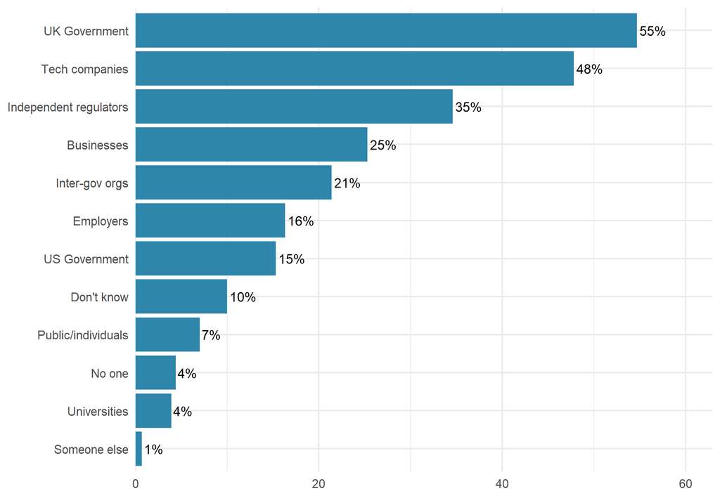

Q3: who should ensure AI is safe and fair (%)

**Reading.** Three actors dominate: UK Government (~55%), tech companies themselves (~48%), independent regulators (~35%). Inter-governmental bodies trail at ~21%. Individual/public responsibility scores ~7% — the public does not see this as a user-managed problem.

## 5.2 Number of actors nominated

Distribution of actors nominated

| # actors named | n | pct |
| --- | --- | --- |
| 1 | 138 | 24.3 |
| 2 | 57 | 10.0 |
| 3 | 374 | 65.7 |

## 5.3 Governance × attitudes (the brief’s ask)

Does how people feel about AI predict who they want in charge?

Governance choice by trust in tech self-regulation

| q2_04_view | Picks Tech cos | Picks UK Gov | Picks Indep. regs | n |
| --- | --- | --- | --- | --- |
| Agrees with self-reg | 43.0 | 50.0 | 20.9 | 86 |
| Disagrees with self-reg | 52.8 | 60.1 | 42.9 | 343 |
| Neutral | 46.9 | 53.1 | 27.2 | 81 |

Q3 preferences by positivity and concern tertiles

| Attitude | Group | UK Gov | Tech cos | Regulators | Inter-gov | n |
| --- | --- | --- | --- | --- | --- | --- |
| Positivity | Low positivity | 60.1 | 46.3 | 40.4 | 23.2 | 203 |
| Positivity | Mid positivity | 54.5 | 55.2 | 39.4 | 25.5 | 165 |
| Positivity | High positivity | 52.0 | 47.5 | 27.1 | 18.6 | 177 |
| Concern | Low concern | 49.3 | 43.8 | 30.3 | 18.9 | 201 |
| Concern | Mid concern | 53.8 | 52.4 | 34.4 | 23.1 | 212 |
| Concern | High concern | 68.4 | 53.4 | 45.1 | 26.3 | 133 |

## 5.4 Brief demographic cross-check

Q3 top actors by key demographics

| Variable | Group | UK Gov | Tech cos | Regs | Inter-gov | n |
| --- | --- | --- | --- | --- | --- | --- |
| Age | 18-24 | 46.0 | 46.0 | 18.0 | 24.0 | 50 |
| Age | 25-34 | 54.3 | 39.5 | 22.2 | 23.5 | 81 |
| Age | 35-44 | 43.9 | 51.0 | 30.6 | 23.5 | 98 |
| Age | 45-54 | 52.6 | 43.2 | 34.7 | 21.1 | 95 |
| Age | 55-64 | 57.4 | 43.6 | 43.6 | 19.8 | 101 |
| Age | 65+ | 64.6 | 56.9 | 43.8 | 19.4 | 144 |
| SEG | A | 61.8 | 52.7 | 40.0 | 18.2 | 55 |
| SEG | B | 47.4 | 47.4 | 37.1 | 26.8 | 97 |
| SEG | C1 | 61.8 | 48.5 | 35.2 | 24.2 | 165 |
| SEG | C2 | 52.4 | 52.4 | 30.2 | 16.7 | 126 |
| SEG | D | 48.6 | 38.9 | 29.2 | 16.7 | 72 |
| SEG | E | 51.9 | 42.6 | 40.7 | 24.1 | 54 |
| Disability | No | 54.1 | 47.5 | 31.4 | 20.8 | 427 |
| Disability | Yes | 56.3 | 48.6 | 44.4 | 23.2 | 142 |

Most demographic variation in Q3 is modest — governance preferences are more stable across the public than attitudes are. The one exception: disabled respondents nominate independent regulators much more often (~44% vs ~31%).

# 6 Aim 4 — Distinct publics (cluster analysis)

*The social fault lines the revolution creates — not just “the public” but distinct mindsets within it.*

The brief: segment on attitudes, profile with *selected* demographic variables, and name the clusters.

## 6.1 Method

K-means on the 10 Q2 items + 5 Q4 items, all standardised. Only respondents with complete data on all 15 variables are used.

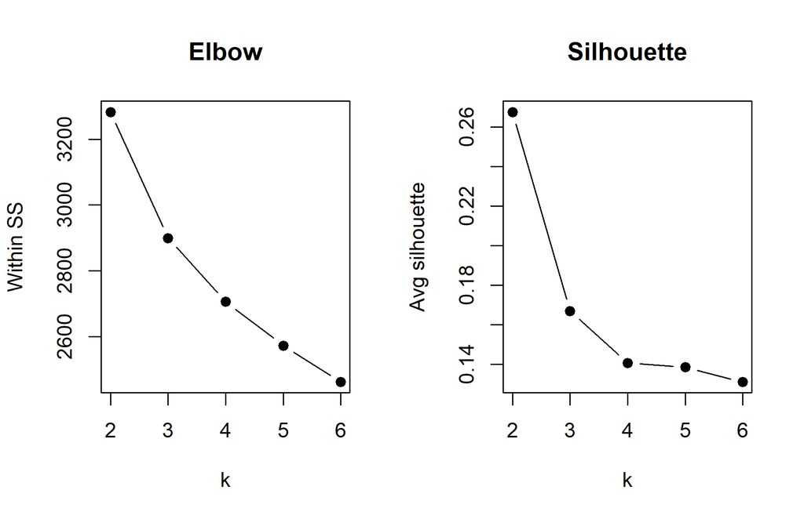

Silhouette and elbow diagnostics

Silhouette favours k = 2; we retain k = 4 for interpretability. The brief asks for segmentation useful for communication — four groups surface the middle ground between the polar extremes. This is a stated trade-off.

## 6.2 Four-cluster solution

| cluster | q2_01 | q2_02 | q2_03 | q2_04 | q2_05 | q2_06 | q2_07 | q2_08 | q2_09 | q2_10 | q4_01 | q4_02 | q4_03 | q4_04 | q4_05 | n |
| --- | --- | --- | --- | --- | --- | --- | --- | --- | --- | --- | --- | --- | --- | --- | --- | --- |
| 1 | 4.30 | 2.55 | 2.61 | 1.97 | 2.71 | 2.45 | 2.48 | 4.04 | 2.62 | 4.30 | 4.96 | 4.13 | 5.97 | 5.13 | 4.65 | 104 |
| 2 | 2.97 | 3.26 | 2.96 | 2.96 | 3.37 | 3.09 | 3.28 | 3.18 | 3.07 | 2.90 | 6.35 | 5.96 | 5.71 | 5.44 | 6.32 | 68 |
| 3 | 4.25 | 4.24 | 3.70 | 3.46 | 4.13 | 4.15 | 4.30 | 3.17 | 3.85 | 3.99 | 7.37 | 6.24 | 6.89 | 6.06 | 7.80 | 71 |
| 4 | 3.98 | 1.34 | 1.93 | 1.22 | 1.49 | 1.20 | 1.37 | 4.49 | 1.61 | 4.55 | 2.40 | 2.07 | 7.38 | 2.91 | 2.21 | 82 |

Cluster profile — selected demographics (% within cluster)

| cluster | n | % 18-34 | % 65+ | % female | % AB | % DE | % uni+ | % weekly AI | % never AI |
| --- | --- | --- | --- | --- | --- | --- | --- | --- | --- |
| 1 | 104 | 19.2 | 30.8 | 41.3 | 29.8 | 21.2 | 59.6 | 50.5 | 21.2 |
| 2 | 68 | 35.3 | 10.3 | 45.6 | 32.4 | 17.6 | 58.8 | 55.2 | 14.9 |
| 3 | 71 | 40.8 | 12.7 | 26.8 | 40.8 | 14.1 | 62.0 | 75.7 | 10.0 |
| 4 | 82 | 17.1 | 29.3 | 54.9 | 22.0 | 24.4 | 51.2 | 18.8 | 55.0 |

## 6.3 Cluster names (proposed — rework as needed)

Working names based on the mean profiles. Swap freely.

Verify against the cluster-means table before publishing — k-means label numbering is arbitrary, so the cluster numbered “3” here may or may not be the enthusiasts on another run. Re-check against the mean profile.

## 6.4 Cluster governance patterns

Selected governance choices by cluster (%)

| cluster | UK Government | Tech companies | Independent regulators | Don’t know |
| --- | --- | --- | --- | --- |
| 1 | 60.6 | 55.8 | 38.5 | 4.8 |
| 2 | 47.1 | 36.8 | 26.5 | 1.5 |
| 3 | 50.7 | 47.9 | 25.4 | 1.4 |
| 4 | 63.4 | 46.3 | 45.1 | 7.3 |

## 6.5 Aim 4 summary

Four stable clusters: Cautious middle, Ambivalent, Enthusiasts, Alarmed. They differ most sharply on positivity and trust in industry self-governance; they agree that AI should be governed and UK Government is the right anchor. The clusters are strongly predicted by age and usage, modestly by SEG, and not meaningfully by secondary demographics.

# 7 Aim 5 — Open-ended hopes and concerns (Q5)

*The lived language of the revolution — what people say in their own words when no answer options are pre-supplied.*

The brief: identify themes, sentiments and language; relate back to the Aim 4 clusters.

## 7.1 Response coverage

Q5 response coverage

| Category | n | pct |
| --- | --- | --- |
| Total rows | 569 | 100.0 |
| Blank | 0 | 0.0 |
| ‘Junk’ (nothing/none/N/A/etc) | 19 | 3.3 |
| Substantive responses | 550 | 96.7 |

Everything below is restricted to **substantive responses** (> 3 characters and not a dismissive token).

## 7.2 Response length

| Metric | Value |
| --- | --- |
| Median words | 11.0 |
| Mean words | 13.3 |
| Max words | 41.0 |

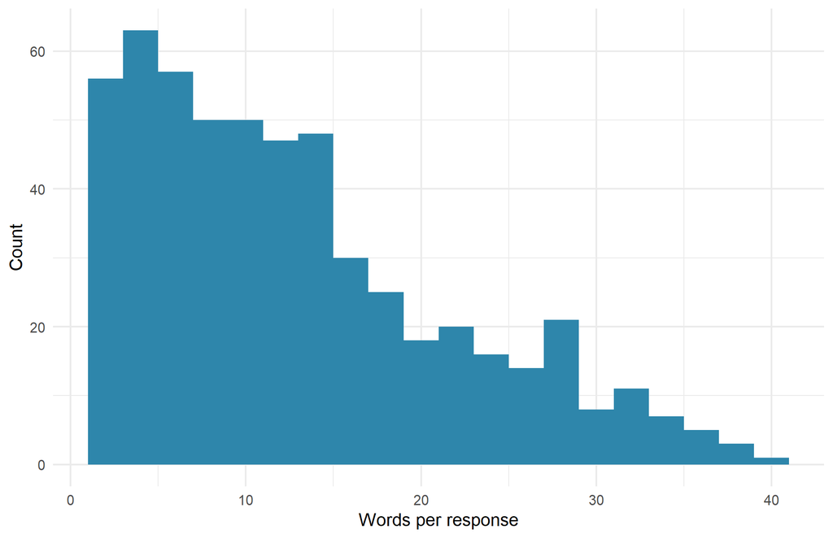

Length of substantive Q5 responses (words)

## 7.3 Top words and bigrams

Top 25 words in substantive Q5 responses

| Word | Count |
| --- | --- |
| people | 125 |
| jobs | 87 |
| hope | 67 |
| concern | 52 |
| main | 49 |
| human | 32 |
| information | 29 |
| help | 27 |
| life | 27 |
| take | 27 |
| don | 26 |
| know | 26 |
| job | 25 |
| loss | 23 |
| out | 23 |
| control | 22 |
| make | 22 |
| like | 21 |
| concerned | 20 |
| privacy | 20 |
| easier | 19 |
| humans | 19 |
| much | 19 |
| data | 18 |
| good | 17 |

Top 15 bigrams (2-word phrases)

| Bigram | Count |
| --- | --- |
| main concern | 33 |
| loss jobs | 16 |
| job losses | 12 |
| main hope | 12 |
| don know | 11 |
| life easier | 8 |
| concern people | 7 |
| jobs people | 7 |
| less jobs | 7 |
| take away | 7 |
| hope help | 6 |
| hope improve | 6 |
| know enough | 6 |
| many people | 6 |
| out control | 6 |

## 7.4 Theme detection (dictionary approach)

Rather than fit an opaque topic model, we pre-specify theme dictionaries and flag each substantive response for each theme. Every classification is traceable to a keyword.

Theme prevalence in Q5 (substantive n = 550)

|  | Theme | n | % of substantive responses |
| --- | --- | --- | --- |
| Jobs & economy | Jobs & economy | 140 | 25.5 |
| Fear & pessimism | Fear & pessimism | 120 | 21.8 |
| Efficiency & benefits | Efficiency & benefits | 96 | 17.5 |
| Hope & optimism | Hope & optimism | 71 | 12.9 |
| Control & autonomy | Control & autonomy | 56 | 10.2 |
| Safety & harm | Safety & harm | 55 | 10.0 |
| Healthcare & medicine | Healthcare & medicine | 44 | 8.0 |
| Privacy & surveillance | Privacy & surveillance | 36 | 6.5 |
| Misinformation & trust | Misinformation & trust | 30 | 5.5 |
| Regulation & governance | Regulation & governance | 28 | 5.1 |
| Creativity & art | Creativity & art | 16 | 2.9 |
| Environment & climate | Environment & climate | 15 | 2.7 |
| Bias, fairness, inequality | Bias, fairness, inequality | 13 | 2.4 |
| Loss of human contact | Loss of human contact | 11 | 2.0 |
| Education & learning | Education & learning | 10 | 1.8 |

## 7.5 Simple sentiment lean

Count of positive- vs negative-leaning words against a small dictionary. Crude but transparent.

Sentiment lean of substantive Q5 responses

| q5_lean | n | pct |
| --- | --- | --- |
| Negative | 150 | 27.3 |
| Mixed/neutral | 299 | 54.4 |
| Positive | 101 | 18.4 |

**Reading.** Free text runs more negative than the Q2 scales do — expected, because open prompts surface what *bothers* respondents, while Q2 is pre-balanced. Treat sentiment lean as a tone indicator, not a replacement for Q2.

## 7.6 Themes × clusters (the brief’s ask)

Do the four clusters raise different concerns in their own words?

% of substantive Q5 responses mentioning each theme, by cluster

| n | Theme | Cluster 1 | Cluster 2 | Cluster 3 | Cluster 4 |
| --- | --- | --- | --- | --- | --- |
| 101 | Jobs & economy | 28.7 | NA | NA | NA |
| 101 | Privacy & surveillance | 6.9 | NA | NA | NA |
| 101 | Loss of human contact | 5.9 | NA | NA | NA |
| 101 | Control & autonomy | 13.9 | NA | NA | NA |
| 101 | Bias, fairness, inequality | 5.0 | NA | NA | NA |
| 101 | Misinformation & trust | 5.0 | NA | NA | NA |
| 101 | Safety & harm | 10.9 | NA | NA | NA |
| 101 | Regulation & governance | 5.9 | NA | NA | NA |
| 101 | Healthcare & medicine | 11.9 | NA | NA | NA |
| 101 | Education & learning | 5.9 | NA | NA | NA |
| 101 | Creativity & art | 3.0 | NA | NA | NA |
| 101 | Environment & climate | 5.0 | NA | NA | NA |
| 101 | Efficiency & benefits | 10.9 | NA | NA | NA |
| 101 | Hope & optimism | 13.9 | NA | NA | NA |
| 101 | Fear & pessimism | 26.7 | NA | NA | NA |
| 65 | Jobs & economy | NA | 20.0 | NA | NA |
| 65 | Privacy & surveillance | NA | 9.2 | NA | NA |
| 65 | Loss of human contact | NA | 0.0 | NA | NA |
| 65 | Control & autonomy | NA | 9.2 | NA | NA |
| 65 | Bias, fairness, inequality | NA | 0.0 | NA | NA |
| 65 | Misinformation & trust | NA | 3.1 | NA | NA |
| 65 | Safety & harm | NA | 6.2 | NA | NA |
| 65 | Regulation & governance | NA | 3.1 | NA | NA |
| 65 | Healthcare & medicine | NA | 3.1 | NA | NA |
| 65 | Education & learning | NA | 0.0 | NA | NA |
| 65 | Creativity & art | NA | 3.1 | NA | NA |
| 65 | Environment & climate | NA | 1.5 | NA | NA |
| 65 | Efficiency & benefits | NA | 15.4 | NA | NA |
| 65 | Hope & optimism | NA | 7.7 | NA | NA |
| 65 | Fear & pessimism | NA | 13.8 | NA | NA |
| 68 | Jobs & economy | NA | NA | 32.4 | NA |
| 68 | Privacy & surveillance | NA | NA | 7.4 | NA |
| 68 | Loss of human contact | NA | NA | 2.9 | NA |
| 68 | Control & autonomy | NA | NA | 4.4 | NA |
| 68 | Bias, fairness, inequality | NA | NA | 0.0 | NA |
| 68 | Misinformation & trust | NA | NA | 2.9 | NA |
| 68 | Safety & harm | NA | NA | 5.9 | NA |
| 68 | Regulation & governance | NA | NA | 1.5 | NA |
| 68 | Healthcare & medicine | NA | NA | 10.3 | NA |
| 68 | Education & learning | NA | NA | 1.5 | NA |
| 68 | Creativity & art | NA | NA | 2.9 | NA |
| 68 | Environment & climate | NA | NA | 0.0 | NA |
| 68 | Efficiency & benefits | NA | NA | 38.2 | NA |
| 68 | Hope & optimism | NA | NA | 17.6 | NA |
| 68 | Fear & pessimism | NA | NA | 20.6 | NA |
| 81 | Jobs & economy | NA | NA | NA | 27.2 |
| 81 | Privacy & surveillance | NA | NA | NA | 4.9 |
| 81 | Loss of human contact | NA | NA | NA | 1.2 |
| 81 | Control & autonomy | NA | NA | NA | 9.9 |
| 81 | Bias, fairness, inequality | NA | NA | NA | 4.9 |
| 81 | Misinformation & trust | NA | NA | NA | 6.2 |
| 81 | Safety & harm | NA | NA | NA | 12.3 |
| 81 | Regulation & governance | NA | NA | NA | 8.6 |
| 81 | Healthcare & medicine | NA | NA | NA | 2.5 |
| 81 | Education & learning | NA | NA | NA | 2.5 |
| 81 | Creativity & art | NA | NA | NA | 6.2 |
| 81 | Environment & climate | NA | NA | NA | 8.6 |
| 81 | Efficiency & benefits | NA | NA | NA | 7.4 |
| 81 | Hope & optimism | NA | NA | NA | 3.7 |
| 81 | Fear & pessimism | NA | NA | NA | 18.5 |

Sentiment lean by cluster (%)

| cluster | Negative | Mixed/neutral | Positive |
| --- | --- | --- | --- |
| 1 | 34.7 | 55.4 | 9.9 |
| 2 | 16.9 | 66.2 | 16.9 |
| 3 | 17.6 | 51.5 | 30.9 |
| 4 | 30.9 | 59.3 | 9.9 |

**Reading.** The cluster structure from the forced-choice items reproduces itself in the free text.

This is the payoff of Aim 5: the open text validates and enriches the Aim 4 segmentation. The clusters describe genuinely different ways of talking about AI, not just statistical artefacts.

## 7.7 Example quotes per cluster

Illustrative Q5 responses per cluster (randomly sampled)

| cluster | q5 |
| --- | --- |
| 1 | We’re just not sure of it’s limits and what it can do and how much it will learn before it gets out of control! Maybe Terminator and Skynet won’t be such a far fetched idea in the future! |
| 1 | take away humanity in all forms |
| 1 | Im worried it could steal identities |
| 2 | AI should cut out human mistakes, work harder and longer, with no risk of human union strikes |
| 2 | The way it will change everything |
| 2 | Concern might be ethical problems, privacy and threat to job opportunities. Hope might be high efficiency, low inequity and standard opportunities for people |
| 3 | It being used for fraud |
| 3 | I think it can streamline and make things easier. It helps be more creative |
| 3 | That we have robots to help with everyday tasks |
| 4 | that it is only used in a way that does not take jobs from people |
| 4 | That it will be misused by those in power. It’s already happening. |
| 4 | My main concern is that no one can mwasure the effect of AI so governments cannot reuly plan any policies of the future impact like employment, education etc |

Read these to sanity-check the named clusters — if the Enthusiast quotes sound enthusiastic and the Alarmed quotes sound alarmed, the labels hold.